# 2018 Customer Data Linear Regression Predictive Modeling

Kimberly Healy | healy.kim@gmx.us

## Background

The data (customer_data_2018.csv) come from the 2018 sales of a small wholesale business. The variables in the raw data set include:

| Variable | Type | Meaning |
| --- | --- | --- |
| Customer.id | integer | Unique customer ID |
| State | string | State customer operates in |
| Last.yr.sales | numeric | 2018 sales amount |
| Prior.yr.sales | numeric | 2017 sales amount |
| Life.orders | numeric | Total amount of sales from customer over the lifetime of the relationship |
| Entry.date | date | Date the customer made a first purchase |
| Cust.type.id | string | Descriptive word to describe customer’s business type |

The following models are used:
**Simple Linear Regression**: a model that estimates the relationship between two continuous variables (one dependent and one independent) using a straight line.
$$Y_i \sim \beta_0 + X_i\beta_1 + \epsilon_i$$

$$\epsilon_i \sim N(0,\sigma^2)$$
**Multiple Linear Regression**: a model that estimates the relationship between one dependent and two or more independent continuous variables using a straight line.

$$Y_i \sim \beta_0 + X_i\beta_1 + X_i\beta_2 + ... + \epsilon_i$$

$$\epsilon \sim N(0,\sigma^2)$$

The following question is answered:  
- **Which model best predicts company sales?**

## I. Load Required Libraries

```r
library(tidyverse)
library(dplyr)
library(lubridate)
library(kableExtra)
```

## II. Load Raw Data

```r
data_raw <- read.csv("customer_data_2018.csv", header = T, stringsAsFactors = F) %>% rename(Sales.2018 = Last.yr.sales)%>% rename(Sales.2017 = Prior.yr.sales)
data<-data_raw
data<-data[-c(1, nrow(data)),]
```

## III. Define Useful Functions

### (i) Significance Tests

$H_{o}: \rho = 0$  
$H_{a}: \rho ≠ 0$

```r
# correlation test
cor.mtest <- function(mat, ...) {
    mat <- as.matrix(mat)
    n <- ncol(mat)
    p.mat<- matrix(NA, n, n)
    diag(p.mat) <- 0
    for (i in 1:(n - 1)) {
        for (j in (i + 1):n) {
            tmp <- cor.test(mat[, i], mat[, j], ...)
            p.mat[i, j] <- p.mat[j, i] <- tmp$p.value
        }
    }
    colnames(p.mat) <- rownames(p.mat) <- colnames(mat)
    p.mat
}
```

## IV. Data Exploration

### (i) Basic Exploration

#### Structure

```r
str(data)
```

```
## 'data.frame':    1044 obs. of  7 variables:
##  $ Customer.id : int  210758 245529 244773 260066 246871 247823 247290 246794 246618 280192 ...
##  $ State       : chr  "FL" "TX" "IL" "NY" ...
##  $ Sales.2018  : int  87727 78201 27240 23086 22642 22400 15278 14587 14343 14269 ...
##  $ Sales.2017  : chr  "101263" "166193" "68006" "22260" ...
##  $ Life.orders : int  299 59 2573 4 134 446 12 150 136 12 ...
##  $ Entry.date  : chr  "2005-02-28" "2009-03-10" "2008-08-29" "2016-03-01" ...
##  $ Cust.type.id: chr  "Gift Basket Home" "Gift Store" "Florist" "Gift Packer" ...
```

```r
data$Customer.id <- as.factor(data$Customer.id)
data$State <- as.factor(data$State)
data$Sales.2018 <- as.numeric(data$Sales.2018)
data$Sales.2017 <- as.numeric(data$Sales.2017)
data$Sales.2017[which(is.na(data$Sales.2017))] <- 0
data$Life.orders <- as.numeric(data$Life.orders)
data$Entry.date <- as.numeric(ymd("2019-01-01")) - as.numeric(ymd(data$Entry.date))
data$Cust.type.id <- as.factor(data$Cust.type.id)
top_10 <- data[1:10,]
```

#### Summary

The summary reveals the following:  
- There were 1044 unique customers in 2018.  
- Lifetime orders and sales values are skewed right, indicating that there are relatively few customers making much larger purchases and few customers are repeating business at a much higher rate than average. Note that these are two groups which may or may not be the same individuals.  
- There were $1,568,867 in sales in 2018 (matching the value on the income statement) and $1,591,916 in sales in 2017 ($217,633.10 less than reported on income statement).

```r
summary(data)
```

```
##   Customer.id       State       Sales.2018        Sales.2017
##  3302   :   1   FL     : 95   Min.   :   34.0   Min.   :     0.0
##  4276   :   1   IL     : 69   1st Qu.:  275.8   1st Qu.:     0.0
##  16822  :   1   PA     : 59   Median :  603.0   Median :   380.5
##  20219  :   1   NY     : 57   Mean   : 1502.8   Mean   :  1524.8
##  20335  :   1   NJ     : 54   3rd Qu.: 1364.0   3rd Qu.:  1182.2
##  21648  :   1   OH     : 49   Max.   :87727.0   Max.   :166193.0
##  (Other):1038   (Other):661
##   Life.orders        Entry.date              Cust.type.id
##  Min.   :   1.00   Min.   :  12   Gift Basket Store:209
##  1st Qu.:   3.00   1st Qu.: 396   Gift Basket Home :207
##  Median :   9.00   Median :1537   Florist          :128
##  Mean   :  24.01   Mean   :2231   Gift Store       : 97
##  3rd Qu.:  23.00   3rd Qu.:3367   Gift Basket      : 78
##  Max.   :2573.00   Max.   :8603   WINERY           : 66
##                                   (Other)          :259
```

```r
Sales.2018.total <- sum(data$Sales.2018)
Sales.2018.total
```

```
## [1] 1568867
```

```r
Sales.2017.total <- sum(data$Sales.2017)
Sales.2017.total
```

```
## [1] 1591916
```

```r
top_10 <- data[1:10,]
top_10
```

```
##    Customer.id State Sales.2018 Sales.2017 Life.orders Entry.date
## 2       210758    FL      87727     101263         299       5055
## 3       245529    TX      78201     166193          59       3584
## 4       244773    IL      27240      68006        2573       3777
## 5       260066    NY      23086      22260           4       1036
## 6       246871    NJ      22642      19978         134       3045
## 7       247823    PA      22400      24981         446       2658
## 8       247290    NJ      15278      10979          12       2913
## 9       246794    IN      14587      17141         150       3084
## 10      246618    FL      14343      16109         136       3171
## 11      280192    IL      14269          0          12        153
##         Cust.type.id
## 2   Gift Basket Home
## 3         Gift Store
## 4            Florist
## 5        Gift Packer
## 6            Florist
## 7            Florist
## 8                UNK
## 9  Gift Basket Store
## 10 Gift Basket Store
## 11        Gift Store
```

#### Distribution of Sales

```r
quantile(data$Sales.2018, probs = seq(0.1,1,0.1))
```

```
##     10%     20%     30%     40%     50%     60%     70%     80%     90%    100%
##   161.3   232.6   326.7   447.4   603.0   805.0  1158.4  1708.8  2961.3 87727.0
```

```r
sum(top_10$Sales.2018)
```

```
## [1] 319773
```

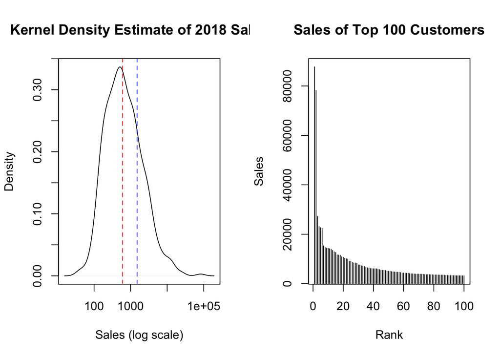

```r
# use log transformation of sales
par(mfrow = c(1,2))
fit <-density(log(data$Sales.2018))
plot(fit,
     xlab = "Sales (log scale)",
     main = "Kernel Density Estimate of 2018 Sales", xaxt = "n"
     )
abline(v = c(log(median(data$Sales.2018)), log(mean(data$Sales.2018))),
       col = c("red", "blue"),
       lty = 2)
axis(side = 1, at = log(c(10,100,1000, 10000, 100000)), labels = c(10,100,1000, 10000, 100000))


# top 100 customer sales
plot(data$Sales.2018[1:100],
     type = "h",
     xlab = "Rank",
     ylab = "Sales",
     main = "Sales of Top 100 Customers")
```

#### New Customers

- There were 347 new customers (customers who bought this year but not last year).
- New customer sales are significantly lower than for customers who bought last year. They also have less variability.
- The median and mean are indicated by red and blue respectively, with dots denoting statistics for new customers. Interestingly 85 of the “new” customers have an entry date prior to 2017.

```r
par(mfrow=c(1,2))
boxplot(log(data$Sales.2018)~data$Sales.2017==0)
new_sales <- data[data$Sales.2017==0,]
summary(new_sales)
```

```
##   Customer.id      State       Sales.2018        Sales.2017  Life.orders
##  23314  :  1   FL     : 34   Min.   :   74.0   Min.   :0    Min.   : 1.000
##  30506  :  1   IL     : 25   1st Qu.:  235.0   1st Qu.:0    1st Qu.: 1.000
##  30776  :  1   NJ     : 22   Median :  396.0   Median :0    Median : 2.000
##  36984  :  1   PA     : 18   Mean   :  760.2   Mean   :0    Mean   : 4.052
##  126396 :  1   TX     : 18   3rd Qu.:  817.5   3rd Qu.:0    3rd Qu.: 4.000
##  207492 :  1   VA     : 18   Max.   :14269.0   Max.   :0    Max.   :86.000
##  (Other):341   (Other):212
##    Entry.date                Cust.type.id
##  Min.   :  12.0   Gift Basket Store:90
##  1st Qu.:  72.5   Gift Basket Home :64
##  Median : 187.0   Gift Basket      :37
##  Mean   : 844.1   Gift Store       :31
##  3rd Qu.: 591.0   Florist          :28
##  Max.   :8399.0   WINE             :16
##                   (Other)          :81
```

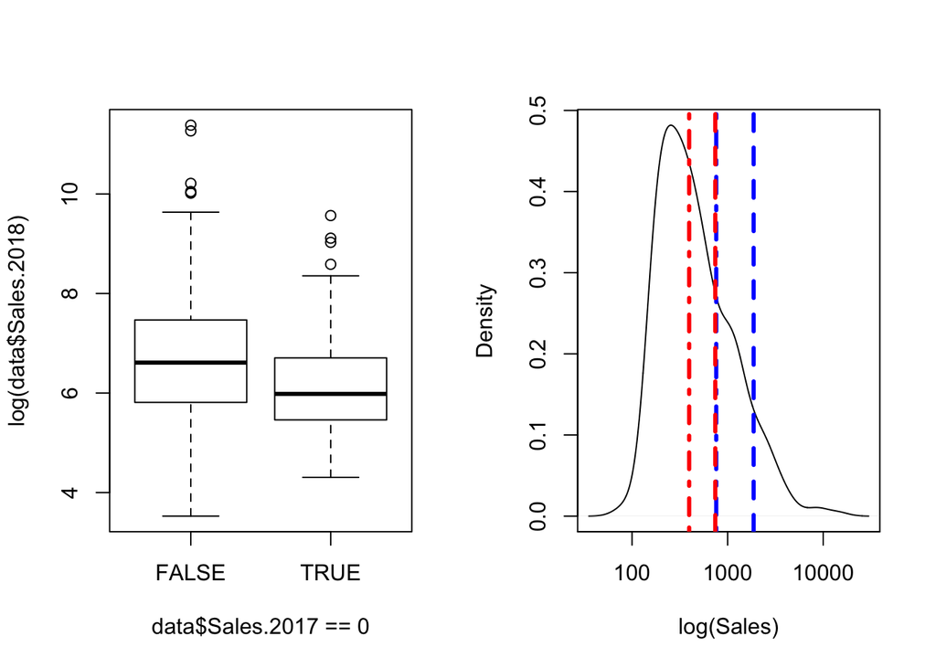

```r
plot(density(log(new_sales$Sales.2018)), xaxt="n", xlab = "log(Sales)", main = "")
axis(side = 1, at = log(c(10,100,1000, 10000, 100000)), labels = c(10,100,1000, 10000, 100000))
abline(v = c(log(median(new_sales$Sales.2018)), log(mean(new_sales$Sales.2018))),
       col = c("red", "blue"),
       lty = 4,
       lwd=3)
abline(v = c(log(median(data[data$Sales.2017>0,]$Sales.2018)), log(mean(data[data$Sales.2017>0,]$Sales.2018))),
       col = c("red", "blue"),
       lty = 2,
       lwd=3)
```

#### Customer Type Breakdown

The table shows the aggregate breakdown of sales by customer type in 2018.

```r
data[,c("Cust.type.id", "Sales.2018")]%>%
  group_by(Cust.type.id)%>%
  summarise_all(c(mean, sum, sd, function(x){sum(x)/mean(x)}))%>%
  arrange(desc(fn2))%>%filter(fn4 >= 10)%>%
  kable(col.names = c("Type", "Average Sales", "Total Sales",  "Std. Dev.", "Count"))
```

| Type | Average Sales | Total Sales | Std. Dev. | Count |
| --- | --- | --- | --- | --- |
| Gift Basket Home | 1489.0048 | 308224 | 6153.4533 | 207 |
| Gift Basket Store | 1269.2584 | 265275 | 2016.5075 | 209 |
| Florist | 1936.3125 | 247848 | 4032.7559 | 128 |
| Gift Store | 2011.1856 | 195085 | 8131.0279 | 97 |
| WINERY | 1369.3636 | 90378 | 2140.7246 | 66 |
| Gift Basket | 1144.0385 | 89235 | 1842.7291 | 78 |
| UNK | 3171.6400 | 79291 | 4502.4527 | 25 |
| WINE | 1128.9434 | 59834 | 1486.4815 | 53 |
| Liquor | 1285.8919 | 47578 | 1369.9038 | 37 |
| Hotel | 1949.8824 | 33148 | 2651.5565 | 17 |
| Specialty Food Store | 1633.7647 | 27774 | 2032.6864 | 17 |
| Grocery | 1296.5714 | 18152 | 1722.9412 | 14 |
| EVENT | 929.0000 | 13006 | 1045.0137 | 14 |
| Tax Exempt Charity | 635.1818 | 6987 | 820.1719 | 11 |
| Restaurant | 673.4000 | 6734 | 803.7395 | 10 |
| CT | 557.2500 | 6687 | 623.8084 | 12 |
| CNSMR | 237.3889 | 4273 | 145.0347 | 18 |

#### Customer Location

Regarding moving the business: Some of the customers are one day closer in shipping time and some are one day farther away. A majority of the top 10 states are in an equally or more favorable location when shipping from LOCATION X.

```r
data[,c("State", "Sales.2018")]%>%
  group_by(State)%>%
  summarise_all(c(mean, sum, sd, function(x){sum(x)/mean(x)}))%>%
  arrange(desc(fn2))%>%head(10)%>%
  kable(col.names = c("Type", "Average Sales",  "Total Sales", "Std. Dev.", "Count"))
```

| Type | Average Sales | Total Sales | Std. Dev. | Count |
| --- | --- | --- | --- | --- |
| FL | 2415.547 | 229477 | 9154.351 | 95 |
| TX | 2953.980 | 144745 | 11169.586 | 49 |
| IL | 1796.986 | 123992 | 4072.504 | 69 |
| NJ | 1977.074 | 106762 | 3895.634 | 54 |
| NY | 1822.439 | 103879 | 3469.061 | 57 |
| PA | 1354.169 | 79896 | 2998.582 | 59 |
| OH | 1413.796 | 69276 | 2043.499 | 49 |
| GA | 1719.026 | 67042 | 3041.499 | 39 |
| CA | 1223.795 | 53847 | 1764.449 | 44 |
| IN | 1289.750 | 46431 | 2546.116 | 36 |

### (ii) Relationships Between Variables

#### Correlations 1

- Strong correlation between 2017 and 2018 sales (r = 0.8751)
- Statistically significant correlation between 2017 and 2018 sales (p-val = 0.029)
- Weak correlation between lifetime orders and 2018 sales (r = 0.3138)

```r
# calculate correlation coefficients
cor_data<-select_if(data, is.numeric)%>%cor()
cor_data
```

```
##             Sales.2018 Sales.2017 Life.orders Entry.date
## Sales.2018  1.00000000 0.87507102   0.3137570 0.09892305
## Sales.2017  0.87507102 1.00000000   0.3527924 0.09523219
## Life.orders 0.31375699 0.35279239   1.0000000 0.18627780
## Entry.date  0.09892305 0.09523219   0.1862778 1.00000000
```

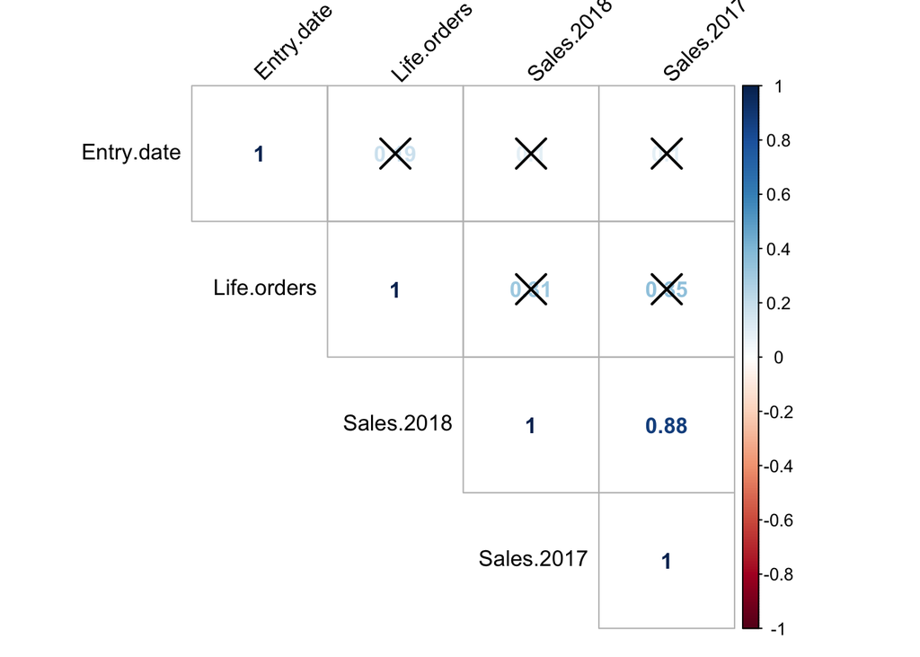

```r
# calculate p-values of correlations
p.mat <- cor.mtest(cor_data)

# plot correlations. X's indicate statistically insignificant correlation
corrplot::corrplot((cor_data),
                   method="number",
                   type="upper", order="hclust", tl.col="black", tl.srt=45,
                   p.mat = p.mat, sig.level = 0.05
)
```

***

#### Correlations 2

- Minimal correlation between the number of days since the customer’s first purchase and 2018 sales

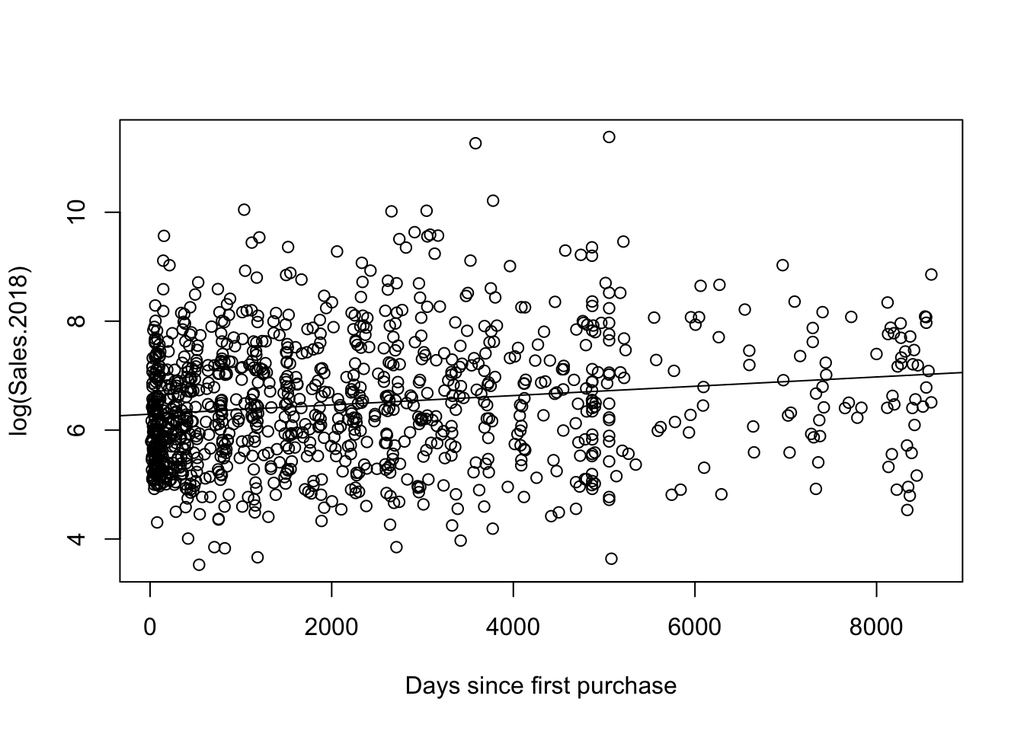

```r
plot(log(Sales.2018)~Entry.date, data=data, xlab = "Days since first purchase", ylab = "log(Sales.2018)")
abline(lm(log(Sales.2018)~Entry.date, data=data))
```

#### ANOVA

- No significant difference between the mean sales among the states (p-val = 0.691)
- There is at least one customer type with a significantly different mean than the others (p-val = 0.00113)
- Pairwise comparison shows that the true mean of the CNSMR category may be significantly lower than several of the others

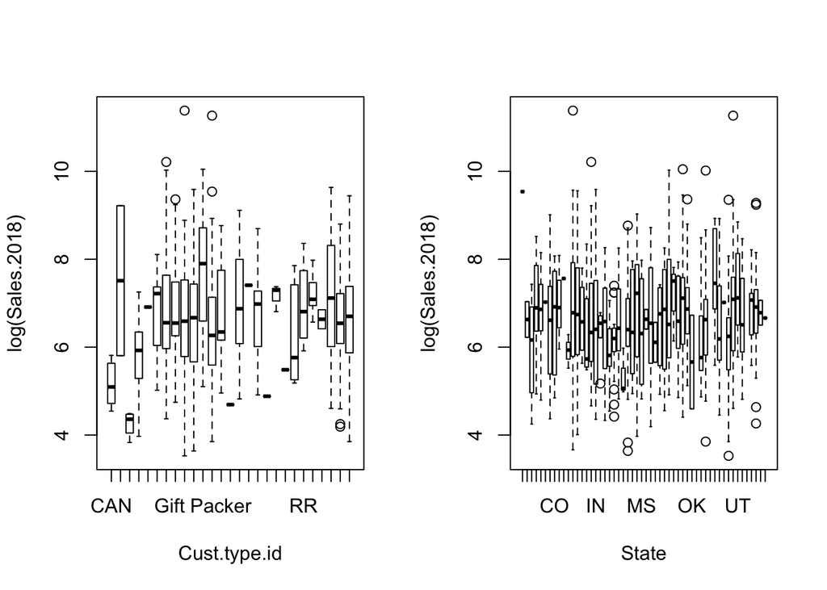

```r
par(mfrow=c(1,2))
boxplot(log(Sales.2018)~Cust.type.id, data=data[data$Sales.2017 > 0, ])
boxplot(log(Sales.2018)~State, data=data[data$Sales.2017 > 0, ])
```

```r
aov1<- aov(log(Sales.2018)~State, data=data[data$Sales.2017 > 0, ])
aov2<- aov(log(Sales.2018)~Cust.type.id, data=data[data$Sales.2017 > 0, ])
summary(aov1)
```

```
##              Df Sum Sq Mean Sq F value Pr(>F)
## State        50   69.4   1.387   0.888  0.691
## Residuals   646 1008.6   1.561
```

```r
summary(aov2)
```

```
##               Df Sum Sq Mean Sq F value  Pr(>F)
## Cust.type.id  26   81.5   3.135   2.108 0.00113 **
## Residuals    670  996.4   1.487
## ---
## Signif. codes:  0 '***' 0.001 '**' 0.01 '*' 0.05 '.' 0.1 ' ' 1
```

```r
SSTr1 <- 81.5
SSE1 <- 996.4
r.sq1 <- 1-SSE1/(SSE1+SSTr1)
T <- TukeyHSD(aov2)
p.vals <- T[[1]][,4]
p.vals <- p.vals[order(p.vals)]
p.vals[1:15]
```

```
##          Gift Packer-CNSMR                  UNK-CNSMR
##                0.002898597                0.003078599
##              Florist-CNSMR                Hotel-CNSMR
##                0.011899511                0.013466155
## Specialty Food Store-CNSMR         Gift Basket -CNSMR
##                0.015696624                0.024083630
##    Gift Basket Store-CNSMR               Liquor-CNSMR
##                0.033778493                0.034193170
##     Gift Basket Home-CNSMR               WINERY-CNSMR
##                0.036971833                0.046442671
##            Gift Packer-CAN           Gift Store-CNSMR
##                0.094657986                0.100302093
##                 WINE-CNSMR                    UNK-CAN
##                0.111827924                0.136970291
##              Grocery-CNSMR
##                0.138487072
```

## V. Modeling Recurring Sales

### (i) SLR: 2018 Sales and 2017 Sales

Fitted regression line  
log(Sales.2018) = 1.1039 + 0.82077(log(Sales.2017))

- No patterns appear in the residual plot. The residuals appear to be randomly scattered around the 0 line and there is a rough horizontal band around the 0 line. The residuals appear to be approx. normally distributed. A rough line is formed in the QQ plot indicating normally distributed data. No apparent outliers.
- p-val < 0.05, indicating there is a significant linear relationship between log(Sales.2018) and log(Sales.2017).
- 63.9% of variation in log(Sales.2018) can be explained by log(Sales.2017) –> the prior year sales model explains 63.98% of the variance in the current year sales.

```r
line1 <- lm(log(Sales.2018)~log(Sales.2017), data=data[data$Sales.2017 > 0, ])
summary(line1)
```

```
##
## Call:
## lm(formula = log(Sales.2018) ~ log(Sales.2017), data = data[data$Sales.2017 >
##     0, ])
##
## Residuals:
##     Min      1Q  Median      3Q     Max
## -3.5412 -0.3926  0.0899  0.4353  2.5764
##
## Coefficients:
##                 Estimate Std. Error t value Pr(>|t|)
## (Intercept)      1.10390    0.16039   6.883 1.31e-11 ***
## log(Sales.2017)  0.82077    0.02336  35.135  < 2e-16 ***
## ---
## Signif. codes:  0 '***' 0.001 '**' 0.01 '*' 0.05 '.' 0.1 ' ' 1
##
## Residual standard error: 0.7474 on 695 degrees of freedom
## Multiple R-squared:  0.6398, Adjusted R-squared:  0.6393
## F-statistic:  1234 on 1 and 695 DF,  p-value: < 2.2e-16
```

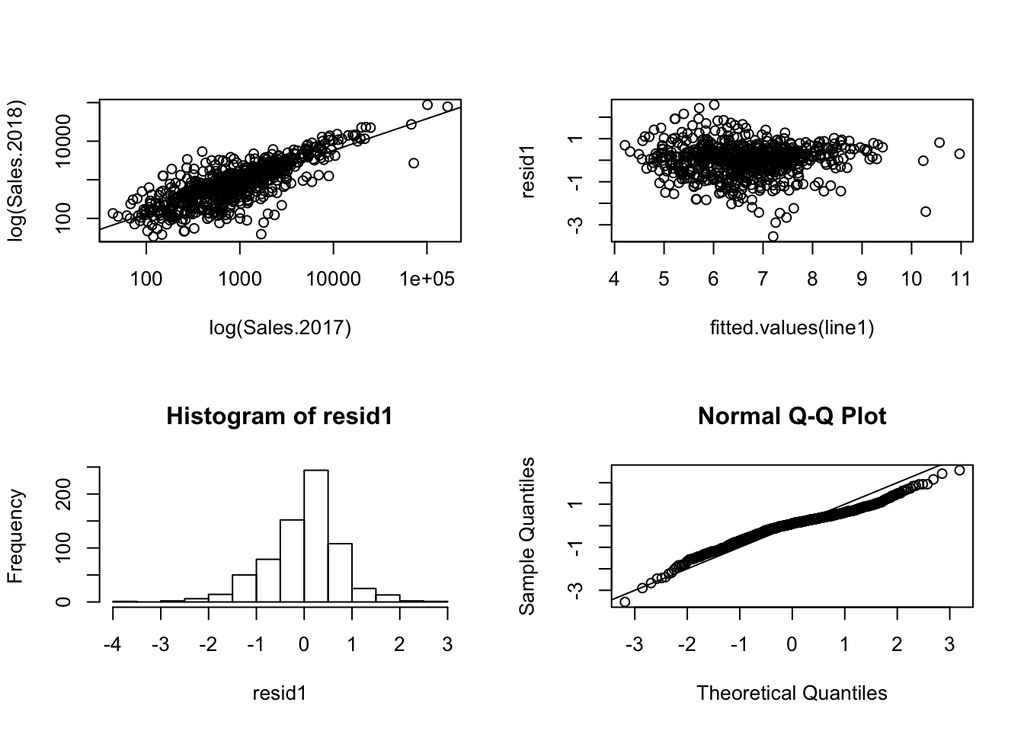

```r
par(mfrow=c(2,2))
plot(log(Sales.2018) ~ log(Sales.2017), data=data[data$Sales.2017 > 0, ], xaxt="n", yaxt="n")
axis(side = 1, at = log(c(10,100,1000, 10000, 100000)), labels = c(10,100,1000, 10000, 100000))
axis(side = 2, at = log(c(10,100,1000, 10000, 100000)), labels = c(10,100,1000, 10000, 100000))
abline(line1$coefficients[1], line1$coefficients[2])
resid1 <- resid(line1)
plot(fitted.values(line1),resid1)
hist(resid1)
qqnorm(resid1)
abline(0,1)
```

### (ii) SLR: 2018 Sales and Lifetime Orders

Fitted regression line  
log(Sales.2018) = 5.21663 + 0.51708(log(Life.orders))

- Linearity assumptions hold.
- p-val < 0.05, indicating there is a significant linear relationship between log(Sales.2018) and log(Life.orders).
- 19.6% of variation in log(Sales.2018) can be explained by log(Life.orders) –> the lifetime orders model explains 19.6% of the variance in the current year sales.

```r
line2 <- lm(log(Sales.2018)~log(Life.orders), data=data[data$Sales.2017 > 0, ])
summary(line2)
```

```
##
## Call:
## lm(formula = log(Sales.2018) ~ log(Life.orders), data = data[data$Sales.2017 >
##     0, ])
##
## Residuals:
##     Min      1Q  Median      3Q     Max
## -3.6437 -0.6984  0.0474  0.7578  4.1135
##
## Coefficients:
##                  Estimate Std. Error t value Pr(>|t|)
## (Intercept)       5.21663    0.11774   44.31   <2e-16 ***
## log(Life.orders)  0.51708    0.03963   13.05   <2e-16 ***
## ---
## Signif. codes:  0 '***' 0.001 '**' 0.01 '*' 0.05 '.' 0.1 ' ' 1
##
## Residual standard error: 1.116 on 695 degrees of freedom
## Multiple R-squared:  0.1968, Adjusted R-squared:  0.1956
## F-statistic: 170.3 on 1 and 695 DF,  p-value: < 2.2e-16
```

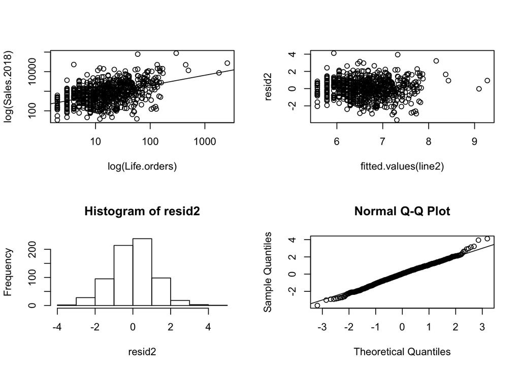

```r
par(mfrow=c(2,2))
plot(log(Sales.2018)~log(Life.orders), data=data[data$Sales.2017 > 0, ], xaxt="n", yaxt="n")
axis(side = 2, at = log(c(10,100,1000, 10000, 100000)), labels = c(10,100,1000, 10000, 100000))
axis(side = 1, at = log(c(10,100,1000, 10000, 100000)), labels = c(10,100,1000, 10000, 100000))
abline(line2$coefficients[1], line2$coefficients[2])
resid2 <- resid(line2)
plot(fitted.values(line2),resid2)
hist(resid2)
qqnorm(resid2)
abline(0,1)
```

***

### (iii) MLR: 2018 Sales, 2017 Sales, Lifetime Orders

Fitted regression line  
log(Sales.2018) = 1.11458 + 0.78584(log(Sales.2017)) + 0.08128(log(Life.orders))

- No interaction in the model.
- p-val < 0.05, indicating there is a significant linear relationship between log(Sales.2018) and log(Sales.2017), log(Life.orders).
- Both variables in model significant to predict log(Sales.2018).
- 64.3% of variation in log(Sales.2018) can be explained by log(Sales.2017) and log(Life.orders).

```r
comb_model <- lm(log(Sales.2018)~log(Sales.2017)+log(Life.orders), data = data[data$Sales.2017>0,])
cs <- summary(comb_model)
print(cs)
```

```
##
## Call:
## lm(formula = log(Sales.2018) ~ log(Sales.2017) + log(Life.orders),
##     data = data[data$Sales.2017 > 0, ])
##
## Residuals:
##     Min      1Q  Median      3Q     Max
## -3.6208 -0.4002  0.0870  0.4184  2.5662
##
## Coefficients:
##                  Estimate Std. Error t value Pr(>|t|)
## (Intercept)       1.11458    0.15973   6.978    7e-12 ***
## log(Sales.2017)   0.78584    0.02665  29.489  < 2e-16 ***
## log(Life.orders)  0.08128    0.03027   2.685  0.00743 **
## ---
## Signif. codes:  0 '***' 0.001 '**' 0.01 '*' 0.05 '.' 0.1 ' ' 1
##
## Residual standard error: 0.7441 on 694 degrees of freedom
## Multiple R-squared:  0.6435, Adjusted R-squared:  0.6425
## F-statistic: 626.3 on 2 and 694 DF,  p-value: < 2.2e-16
```

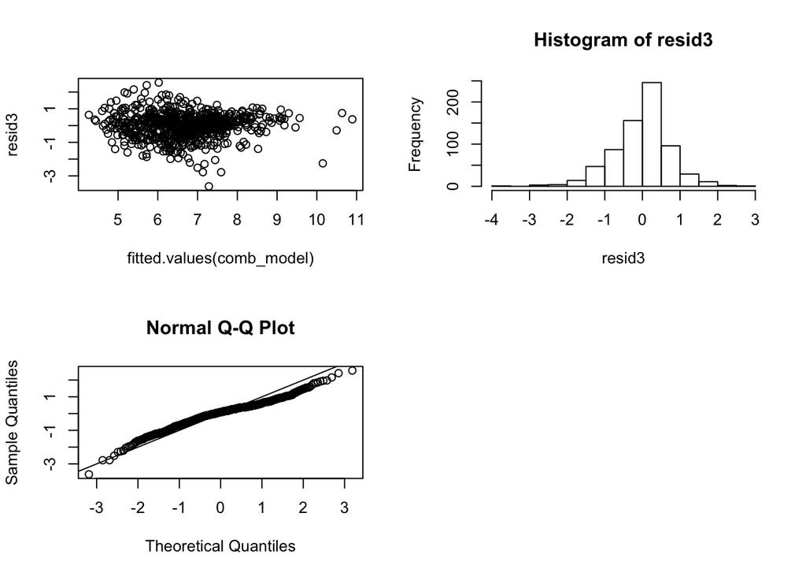

```r
par(mfrow=c(2,2))
resid3 <- resid(comb_model)
plot(fitted.values(comb_model),resid3)
hist(resid3)
qqnorm(resid3)
abline(0,1)
```

***

## VI. Model Limitations & Conclusion

These models are severely limited by lack of data. Namely more years of data. Since 2018 sales were lower than 2017 sales, the model expects them to decline further. Ownership has stated that 2017 is an outlier year (with more sales than usual due to a few individuals placing large orders). With the lack of information and this insight, making predictions with these models would be misleading.

**The combined linear model (MLR) explained slightly more of the variance than the best simple model, adjusting for the complexity of the models.**